**S2 Statistika Terapan · FMIPA UNPAD** Berita Akademik

Berita Akademik · Angkatan 2026

# Hari Pertama Perkuliahan Mahasiswa Baru S2 Statistika Terapan.

Perkuliahan perdana berlangsung sejak pagi hingga sore dengan tiga mata kuliah inti, menandai dimulainya perjalanan akademik mahasiswa baru Program Studi Magister Statistika Terapan FMIPA Universitas Padjadjaran.

📅 18 Agustus 2026 🕢 07.30–16.20 WIB 🎓 Mahasiswa Baru Angkatan 2026 📍 S2 Statistika Terapan FMIPA UNPAD

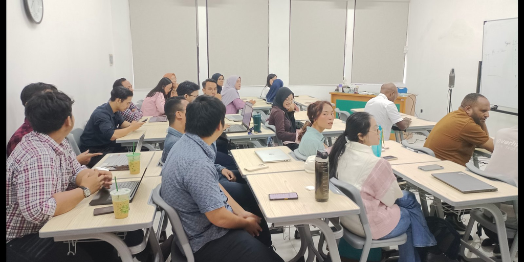

**Suasana pembelajaran hari pertama.** Dokumentasi perkuliahan mahasiswa baru Angkatan 2026

Awal Semester

## Satu hari penuh untuk membangun fondasi belajar.

Rangkaian pembelajaran pada hari pertama dirancang untuk memperkenalkan fondasi komputasi, pemodelan stokastik, dan analisis regresi tingkat lanjut dalam suasana kelas yang aktif, terarah, dan berorientasi capaian.

Pada **18 Agustus 2026**, mahasiswa baru **Angkatan 2026 Program Studi Magister Statistika Terapan FMIPA Universitas Padjadjaran** memulai proses pembelajaran hari pertama. Kegiatan akademik berlangsung mulai pukul **07.30 hingga 16.20 WIB**.

Hari pertama diisi oleh tiga mata kuliah yang merepresentasikan kompetensi penting statistika terapan: **Komputasi Statistik dan Optimasi**, **Proses Stokastik Tingkat Lanjut**, dan **Analisis Regresi Tingkat Lanjut**. Selain penguatan konsep, mahasiswa diarahkan untuk mengembangkan kemampuan analitis, komputasional, pemodelan, dan penyelesaian masalah berbasis data.

Proses belajar mengajar dilaksanakan dengan pendekatan **Outcome-Based Education (OBE)**, sehingga aktivitas pembelajaran, tugas, asesmen, dan umpan balik diarahkan secara konsisten pada capaian pembelajaran yang telah ditetapkan dalam kurikulum.

Fokus Pembelajaran **Belajar bukan sekadar menyelesaikan materi, tetapi memastikan mahasiswa mencapai kompetensi yang dapat dibuktikan melalui asesmen.**

Agenda Hari Pertama

## Tiga mata kuliah, satu arah kompetensi.

Rangkaian mata kuliah pada hari pertama mempertemukan metode komputasi, probabilitas stokastik, serta pemodelan regresi sebagai bekal analisis statistik tingkat lanjut.

01

### Komputasi Statistik dan Optimasi

Penguatan komputasi untuk pemecahan persoalan statistik serta pengenalan kerangka optimasi yang digunakan dalam pemodelan dan inferensi.

Dr. Bertho Tantular

02

### Proses Stokastik Tingkat Lanjut

Pendalaman proses acak dan struktur probabilistik yang menjadi dasar untuk memodelkan fenomena dinamis dan ketidakpastian.

Dr. Irlandia Ginanjar

03

### Analisis Regresi Tingkat Lanjut

Pendalaman pemodelan regresi, diagnosis model, interpretasi, dan pendekatan analitik untuk kasus data yang lebih kompleks.

Prof. I Gede Nyoman Mindra Jaya, Ph.D

Kurikulum Berbasis OBE

## Pembelajaran dirancang dari capaian yang ingin dibuktikan.

Dalam pendekatan OBE, setiap pertemuan menghubungkan capaian lulusan dan capaian mata kuliah dengan aktivitas pembelajaran, asesmen, rubrik, hasil belajar mahasiswa, serta evaluasi untuk perbaikan berkelanjutan.

CPL

CPMK / Sub-CPMK

Aktivitas Pembelajaran

Asesmen & Rubrik

Capaian Mahasiswa

Evaluasi & CQI

Akses Akademik

### Materi, RPS, dan Kurikulum tersedia melalui web program studi.

Mahasiswa dapat mengakses dokumen kurikulum, RPS mata kuliah, serta materi pembelajaran melalui halaman akademik S2 Statistika Terapan FMIPA UNPAD.

[Buka Materi & Kurikulum ↗](https://statistika-unpad.github.io/pasca-statistika-web/#kurikulum)

Dokumentasi

## Suasana kelas pada perkuliahan perdana.

Mahasiswa mengikuti pembelajaran dengan dukungan perangkat komputasi dan aktivitas diskusi sebagai bagian dari proses belajar statistika terapan pada jenjang magister.

[figure not shown]

Interaksi pembelajaran di kelas pada hari pertama perkuliahan.

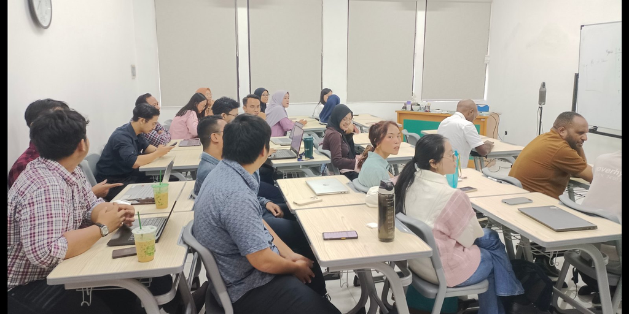

Suasana kelas mahasiswa baru Angkatan 2026 S2 Statistika Terapan FMIPA UNPAD.

Portal Akademik Terpadu

## Materi, RPS, dan Kurikulum dapat diakses langsung dari web program studi.

Mahasiswa dapat membuka struktur kurikulum, dokumen kurikulum, daftar mata kuliah, silabus, RPS, materi kuliah, dokumen PBM, serta Laporan OBE dari satu halaman akademik terpadu.

statistika-unpad.github.io/pasca-statistika-web/#kurikulum

[Buka Web Kurikulum ↗](https://statistika-unpad.github.io/pasca-statistika-web/#kurikulum)

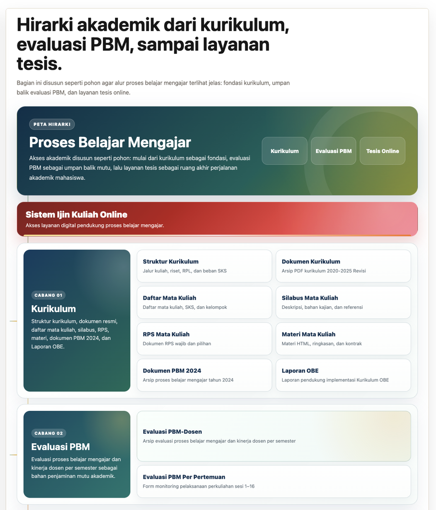

### Akses akademik mahasiswa

Gunakan portal ini sebagai pintu utama untuk melihat Kurikulum OBE, RPS, materi pembelajaran, dan dokumen pendukung proses belajar mengajar.

https://statistika-unpad.github.io/pasca-statistika-web/#kurikulum

[Kunjungi Portal Akademik ↗](https://statistika-unpad.github.io/pasca-statistika-web/#kurikulum)